# Semester 3 Coding Portfolio Topic 2 Summative:

# Natural Language Processing

In this notebook, you are asked to do original work with little guidance, based on the skills you learned in the formative part (as well as lectures and workshops). This section is graded not just on passing automated tests, but also on quality, originality, and effort (see assessment criteria in the assignment description).

```python
# TODO: Please enter your student number here
STUDENT_NUMBER = 15854493
```

# SUMMATIVE ASSESSMENT

For this summative assignment, we ask you to find a dataset from an internet source of choice. You will then create an NLP pipeline including preprocessing, NLP analysis, and classification. Your anlysis for this notebook should have two parts: An initial NLP analysis (as done in formative notebook 1), and a classification of these results (as done in formative notebook 2). Chose one method for each of these two steps.

You should chose ONE of the following:

- Sentiment Analysis
- LDA
- BertTopic

You should ALSO chose ONE of the following:

- Decision Tree / Random Forest
- LLM-based text classification

The general assessment criteria for all summative assignments are mentioned in the assignment description on Canvas. Each notebook also has a few specific criteria we look for; make sure you fulfil them in your approach to this assignment. In general, make sure this notebook represents a complete project: Write an explanation of what you are hoping to achieve with your analysis, document your code well, and present results in a comprehensive way. The assessment criteria for this notebook vary slightly depending on which methods you chose to implement:

## Sentiment Analysis

- Selected an appropriate dataset and prepared it for analysis, including cleaning and formatting the data.
- Effectively pre-processed the text data, including steps such as tokenization, stopword removal, lemmatization, and handling special characters.
- Selected an appropriate sentiment analysis model or algorithm for their dataset and correctly implemented the sentiment analysis model, ensuring it is properly trained and tested.
- Provided a clear and insightful interpretation of the sentiment analysis results, explaining the significance and implications of their findings.

## LDA

- Selected an appropriate dataset and prepared it for analysis, including cleaning and formatting the data.
- Correctly created a document-term matrix or equivalent representation suitable for LDA.
- Selected appropriate parameters for the LDA model, such as the number of topics and hyperparameters.
- Correctly implemented the LDA model, ensuring it is properly trained on the dataset.
- Provided a clear and insightful interpretation of the topics, explaining the significance and relevance of the discovered topics.

## BertTopic

- Selected an appropriate dataset and prepared it for analysis, including cleaning and formatting the data.
- Correctly generated text embeddings using a suitable model for input into BERTopic.
- Correctly implemented the BERTopic model, ensuring it is properly trained on the dataset.
- Accurately extracted and represented topics from the BERTopic model.
- Provided a clear and insightful interpretation of the topics, explaining the significance and relevance of the discovered topics.

## Decision Tree / Random Forest

- Formulated a relevant and appropriate classification objective for the NLP task.
- Pre-processed the text data appropriately, including vecterization and other necessary steps.
- Properly trained and tested the decision tree or random forest model.
- Accurately print or visualize the results, or provide insightful interpretation of the findings.

## LLM-based text classification

- Formulated a relevant and appropriate classification objective for the NLP task.
- Correctly prepared the data for the LLM, ensuring it is suitable for model input.
- Properly ran the LLM and tested the LLM output.
- Accurately print or visualize the results, or provide insightful interpretation of the findings.

Pick a dataset of your choice. Please ensure your dataset is a csv file under 100MB named sem3_topic2_nlp_summative_data.csv

```python
# Do NOT modify the contents of this cell. Start your customization in the next one!
import pandas as pd

custom_data_path = "sem3_topic2_nlp_summative_data.csv"
custom_df = pd.read_csv(custom_data_path)
```

## BACKSTORY

Religion has always been an interesting topic for me. My parents never baptised me, choosing instead to let me decide my own beliefs when I was old enough. Still, my mother is strongly Orthodox, so growing up we celebrated Christmas on the night of the 6th to the 7th of January.

Now, living in Amsterdam, I have a Christian boyfriend. This year I will be joining his family for a Catholic Christmas celebration. They are very religious people, and as a respectful girlfriend I decided to use this summative project as an opportunity to impress my “mother-in-law” with my growing Bible knowledge.

So in this notebook I will be **(1) exploring different topics that emerge throughout Bible verses**, and **(2) training a model to classify each verse into its discovered topic.**

the image was generated with ChatGPT

[figure not shown]

```python
import json
import pandas as pd
import numpy as np
import re
import matplotlib.pyplot as plt
import seaborn as sns

from bertopic import BERTopic
from sklearn.feature_extraction.text import CountVectorizer, TfidfVectorizer
from sklearn.model_selection import train_test_split
from sklearn.ensemble import RandomForestClassifier
from sklearn.metrics import accuracy_score, classification_report, confusion_matrix
from sklearn.feature_extraction.text import ENGLISH_STOP_WORDS
```

## SET UP & LOAD DATA

```python
#load json data & convert into df
with open("ASV.json", "r") as f:
    data = json.load(f)

rows = []
for book in data["books"]:
    for chapter in book["chapters"]:
        for verse in chapter["verses"]:
            rows.append({
                "book": book["name"],
                "chapter": chapter["chapter"],
                "verse": verse["verse"],
                "text": verse["text"]
            })

df = pd.DataFrame(rows)
df.to_csv("sem3_topic2_nlp_summative_data.csv", index=False, quoting=1) #save to csv

print(f"Total verses: {len(df)}")
print(f"Total books: {df['book'].nunique()}")
df.head()
```

```
Total verses: 31102
Total books: 66
```

|  | book | chapter | verse | text |
| --- | --- | --- | --- | --- |
| 0 | Genesis | 1 | 1 | In the beginning God created the heavens and t... |
| 1 | Genesis | 1 | 2 | And the earth was waste and void; and darkness... |
| 2 | Genesis | 1 | 3 | And God said, Let there be light: and there wa... |
| 3 | Genesis | 1 | 4 | And God saw the light, that it was good: and G... |
| 4 | Genesis | 1 | 5 | And God called the light Day, and the darkness... |

## ADDING GENRE LABELS

**Genre labels source:** Genre classifications based on standard Biblical literary categories (Wikipedia: https://en.wikipedia.org/wiki/Biblical_genre).

**Belwo I decided to add** truth values** in order to cope with the fact that BERTopic discovers topics without label knowledge. In order to later on be able to evaluate my classifier (random forest), adding those truth values is beneficial. Essentially it will allow me to compare model's classification against them to get model accuracy score**

Each Bible book has each correct genre:

- **Law** (Genesis-Deuteronomy): Instructions and commandments
- **History** (Joshua, Judges, Kings, etc.): Historical narratives
- **Poetry** (Psalms, Song of Solomon): Poetic and lyrical texts
- **Wisdom** (Job, Proverbs, Ecclesiastes): Philosophical reflections
- **Prophecy** (Isaiah-Malachi): Prophetic messages
- **Gospel** (Matthew-John): Accounts of Jesus' life
- **Epistle** (Romans-Jude): Letters to early churches
- **Apocalyptic** (Revelation): Symbolic visions of end times

**Genre labels source:** Genre classifications based on standard Biblical literary categories (Wikipedia: https://en.wikipedia.org/wiki/Biblical_genre).

This gives me labeled data to:

1. Train the Random Forest to recognize genre patterns
2. Test how accurately it can predict genres from text alone

```python
#mapping each book to its genre
book_to_genre = {
    # Law/Pentateuch - first 5 books
    "Genesis": "Law", "Exodus": "Law", "Leviticus": "Law",
    "Numbers": "Law", "Deuteronomy": "Law",

    # History/Old Testament
    "Joshua": "History", "Judges": "History", "Ruth": "History",
    "1 Samuel": "History", "2 Samuel": "History",
    "1 Kings": "History", "2 Kings": "History",
    "1 Chronicles": "History", "2 Chronicles": "History",
    "Ezra": "History", "Nehemiah": "History", "Esther": "History",

    # Poetry & Wisdom
    "Job": "Wisdom", "Psalms": "Poetry", "Proverbs": "Wisdom",
    "Ecclesiastes": "Wisdom", "Song of Solomon": "Poetry",

    # Prophecy/Major Prophets
    "Isaiah": "Prophecy", "Jeremiah": "Prophecy",
    "Lamentations": "Poetry", "Ezekiel": "Prophecy", "Daniel": "Prophecy",

    # Prophecy/Minor Prophets
    "Hosea": "Prophecy", "Joel": "Prophecy", "Amos": "Prophecy",
    "Obadiah": "Prophecy", "Jonah": "Prophecy", "Micah": "Prophecy",
    "Nahum": "Prophecy", "Habakkuk": "Prophecy", "Zephaniah": "Prophecy",
    "Haggai": "Prophecy", "Zechariah": "Prophecy", "Malachi": "Prophecy",

    # Gospels
    "Matthew": "Gospel", "Mark": "Gospel", "Luke": "Gospel", "John": "Gospel",

    # History/New Testament
    "Acts": "History",

    # Epistles/Letters
    "Romans": "Epistle", "1 Corinthians": "Epistle", "2 Corinthians": "Epistle",
    "Galatians": "Epistle", "Ephesians": "Epistle", "Philippians": "Epistle",
    "Colossians": "Epistle", "1 Thessalonians": "Epistle", "2 Thessalonians": "Epistle",
    "1 Timothy": "Epistle", "2 Timothy": "Epistle", "Titus": "Epistle", "Philemon": "Epistle",
    "Hebrews": "Epistle", "James": "Epistle", "1 Peter": "Epistle", "2 Peter": "Epistle",
    "1 John": "Epistle", "2 John": "Epistle", "3 John": "Epistle", "Jude": "Epistle",

    # Apocalyptic
    "Revelation": "Apocalyptic"
}

#add new genre column to df
df["genre"] = df["book"].map(book_to_genre)

#check for any unmapped books
print("Genre distribution:")
print(df["genre"].value_counts())
```

```
Genre distribution:
genre
Law         5852
Prophecy    5336
Gospel      3779
History     3221
Poetry      2732
Wisdom      2207
Epistle     1443
Name: count, dtype: int64
```

## GROUP VERSES INTO CHAPTERS

**when first running bertopic on my verses plainly, I noticed the results did not make sense, so I decided to increase the text volume into chapters because short texts (some verses are 3 words) do not work for topic modelling**

```python
#group by => book + chapter, combine text, keep genre
chapter_df = df.groupby(["book", "chapter", "genre"]).agg({
    "text": " ".join
}).reset_index()

#cleaning minimal for BERTopic since it has its own preprocessing
chapter_df["clean_text"] = chapter_df["text"].apply(lambda x: re.sub(r"\s+", " ", x).strip())

print(f"Total chapters: {len(chapter_df)}")
print(f"Avg words per chapter: {chapter_df['clean_text'].str.split().str.len().mean():.0f}")
chapter_df.head()
```

```
Total chapters: 938
Avg words per chapter: 642
```

|  | book | chapter | genre | text | clean_text |
| --- | --- | --- | --- | --- | --- |
| 0 | Acts | 1 | History | The former treatise I made, O Theophilus, conc... | The former treatise I made, O Theophilus, conc... |
| 1 | Acts | 2 | History | And when the day of Pentecost was now come, th... | And when the day of Pentecost was now come, th... |
| 2 | Acts | 3 | History | Now Peter and John were going up into the temp... | Now Peter and John were going up into the temp... |
| 3 | Acts | 4 | History | And as they spake unto the people, the priests... | And as they spake unto the people, the priests... |
| 4 | Acts | 5 | History | But a certain man named Ananias, with Sapphira... | But a certain man named Ananias, with Sapphira... |

## BERTopic ANALYSIS

BERTopic discovers topics automatically by:

1. Converting text to embeddings (numbers)
2. Clustering similar documents
3. Finding representative words for each cluster

PS: I also used a custom **stop-word list** because Bible has a very specific language and regular english stop words do not make sense in this context

```python
#custom stopwords for biblical text
biblical_stopwords = [
    "thou", "thee", "thy", "thine", "thyself", "ye", "hath", "hast",
    "doth", "dost", "art", "wast", "shalt", "wilt", "didst", "unto",
    "thereof", "wherefore", "hereby", "behold", "verily", "yea",
    "said", "saying", "came", "went", "shall", "also", "upon"
]

#combine with English stopwords regular

all_stopwords = list(ENGLISH_STOP_WORDS) + biblical_stopwords

# Create vectorizer with stopwords
vectorizer = CountVectorizer(stop_words=all_stopwords, min_df=2)

# Create and train BERTopic
topic_model = BERTopic(
    vectorizer_model=vectorizer,
    min_topic_size=15,
    verbose=True
)

documents = chapter_df["clean_text"].tolist()
topics, probs = topic_model.fit_transform(documents)

print(f"\nFound {len(set(topics)) - 1} topics (excluding outliers)")
```

```
2025-12-05 11:44:07,843 - BERTopic - Embedding - Transforming documents to embeddings.
```

```
2025-12-05 11:44:17,691 - BERTopic - Embedding - Completed ✓
2025-12-05 11:44:17,692 - BERTopic - Dimensionality - Fitting the dimensionality reduction algorithm
2025-12-05 11:44:21,014 - BERTopic - Dimensionality - Completed ✓
2025-12-05 11:44:21,015 - BERTopic - Cluster - Start clustering the reduced embeddings
2025-12-05 11:44:21,036 - BERTopic - Cluster - Completed ✓
2025-12-05 11:44:21,042 - BERTopic - Representation - Fine-tuning topics using representation models.
2025-12-05 11:44:21,208 - BERTopic - Representation - Completed ✓
```

```
Found 10 topics (excluding outliers)
```

```python
#view topics
topic_info = topic_model.get_topic_info()
print("Topics discovered:")
topic_info.head(15)
```

```
Topics discovered:
```

|  | Topic | Count | Name | Representation | Representative_Docs |
| --- | --- | --- | --- | --- | --- |
| 0 | -1 | 276 | -1_god_jehovah_man_children | [god, jehovah, man, children, king, israel, da... | [And God spake all these words, saying, I am J... |
| 1 | 0 | 323 | 0_jehovah_saith_land_god | [jehovah, saith, land, god, king, people, isra... | [Woe unto the shepherds that destroy and scatt... |
| 2 | 1 | 67 | 1_jesus_man_disciples_son | [jesus, man, disciples, son, say, things, pete... | [Now after two days wasthe feast ofthe passove... |
| 3 | 2 | 46 | 2_priest_jehovah_unclean_offer | [priest, jehovah, unclean, offer, altar, burnt... | [And Jehovah spake unto Moses, saying, Speak u... |
| 4 | 3 | 45 | 3_children_son_israel_thousand | [children, son, israel, thousand, tribe, famil... | [Now Joshua was old and well stricken in years... |
| 5 | 4 | 43 | 4_god_man_heart_let | [god, man, heart, let, soul, time, mouth, know... | [Then answered Eliphaz the Temanite, and said,... |
| 6 | 5 | 36 | 5_moses_jehovah_people_land | [moses, jehovah, people, land, israel, aaron, ... | [And Jehovah said unto Moses, Go in unto Phara... |
| 7 | 6 | 28 | 6_jacob_joseph_father_land | [jacob, joseph, father, land, brethren, laban,... | [And Joseph fell upon his father’s face, and w... |
| 8 | 7 | 27 | 7_christ_god_things_jesus | [christ, god, things, jesus, lord, sin, grace,... | [Now we that are strong ought to bear the infi... |
| 9 | 8 | 25 | 8_wicked_man_righteous_fool | [wicked, man, righteous, fool, wise, heart, po... | [A wise sonhearethhis father’s instruction; Bu... |
| 10 | 9 | 22 | 9_paul_jews_god_lord | [paul, jews, god, lord, certain, things, spiri... | [And it came to pass, that, while Apollos was ... |

```python
#visual for top topics
topic_model.visualize_barchart(top_n_topics=8)
```

[interactive chart not shown]

## Interpreting BERTopic Results

It's interesting that BERTopic managed to separate these themes without knowing anything about the Bible beforehand. Topic 1 especially makes sense since the Gospels have very different vocabulary (talking about Jesus) compared to the Old Testament.

```python
# Add topic assignments to dataframe
chapter_df["topic"] = topics

# Compare discovered topics with known genres
print("\nTopics vs Genres (crosstab):")
pd.crosstab(chapter_df["topic"], chapter_df["genre"])
```

```
Topics vs Genres (crosstab):
```

| genre topic | Epistle | Gospel | History | Law | Poetry | Prophecy | Wisdom |
| --- | --- | --- | --- | --- | --- | --- | --- |
| -1 | 27 | 25 | 40 | 56 | 35 | 59 | 34 |
| 0 | 0 | 0 | 6 | 20 | 115 | 177 | 5 |
| 1 | 0 | 60 | 7 | 0 | 0 | 0 | 0 |
| 2 | 1 | 0 | 1 | 42 | 1 | 1 | 0 |
| 3 | 1 | 1 | 27 | 13 | 0 | 3 | 0 |
| 4 | 3 | 1 | 0 | 0 | 9 | 3 | 27 |
| 5 | 0 | 0 | 4 | 31 | 0 | 1 | 0 |
| 6 | 0 | 0 | 4 | 24 | 0 | 0 | 0 |
| 7 | 26 | 1 | 0 | 0 | 0 | 0 | 0 |
| 8 | 1 | 0 | 0 | 1 | 3 | 1 | 19 |
| 9 | 0 | 1 | 21 | 0 | 0 | 0 | 0 |

## RANDOM FOREST CLASSIFICATION

**Goal:** Train a model to classify Bible chapters into genres based on their text.

**Steps:**

1. Convert text to numbers (TF-IDF)
2. Split into train/test sets
3. Train Random Forest
4. Evaluate accuracy

```python
#prep data
X = chapter_df["clean_text"].values  #text
y = chapter_df["genre"].values       #labels = genres

#split: 80% train, 20% test
X_train, X_test, y_train, y_test = train_test_split(
    X, y, test_size=0.2, random_state=42, stratify=y
)

print(f"Training samples: {len(X_train)}")
print(f"Testing samples: {len(X_test)}")
```

```
Training samples: 750
Testing samples: 188
```

```python
#text to embeddings with TF-IDF
tfidf = TfidfVectorizer(stop_words=all_stopwords, max_features=3000)

X_train_tfidf = tfidf.fit_transform(X_train)
X_test_tfidf = tfidf.transform(X_test)

print(f"Features (vocabulary size): {X_train_tfidf.shape[1]}")
```

```
Features (vocabulary size): 3000
```

```python
#tran random forest
rf = RandomForestClassifier(n_estimators=100, random_state=42)
rf.fit(X_train_tfidf, y_train)

#predict
y_pred = rf.predict(X_test_tfidf)

#accuracy
accuracy = accuracy_score(y_test, y_pred)
print(f"Accuracy: {accuracy:.2%}")
```

```
Accuracy: 87.23%
```

```python
#print classification report
print("Classification Report:")
print(classification_report(y_test, y_pred))
```

```
Classification Report:
              precision    recall  f1-score   support

     Epistle       1.00      1.00      1.00        12
      Gospel       0.89      0.94      0.92        18
     History       0.88      0.64      0.74        22
         Law       0.92      0.92      0.92        37
      Poetry       0.85      0.85      0.85        33
    Prophecy       0.80      0.96      0.87        49
      Wisdom       1.00      0.71      0.83        17

    accuracy                           0.87       188
   macro avg       0.90      0.86      0.87       188
weighted avg       0.88      0.87      0.87       188
```

## Interpreting the Classification Report

**Overall accuracy: 87%** - the model correctly classifies 87% of chapters.

**Key observations:**

**Why some genres are harder to classify:**

- History, Law, and Gospel all contain narrative text, causing some overlap
- Wisdom and Poetry share similar literary features
- Prophecy is the largest class, so the model may be biased toward predicting it

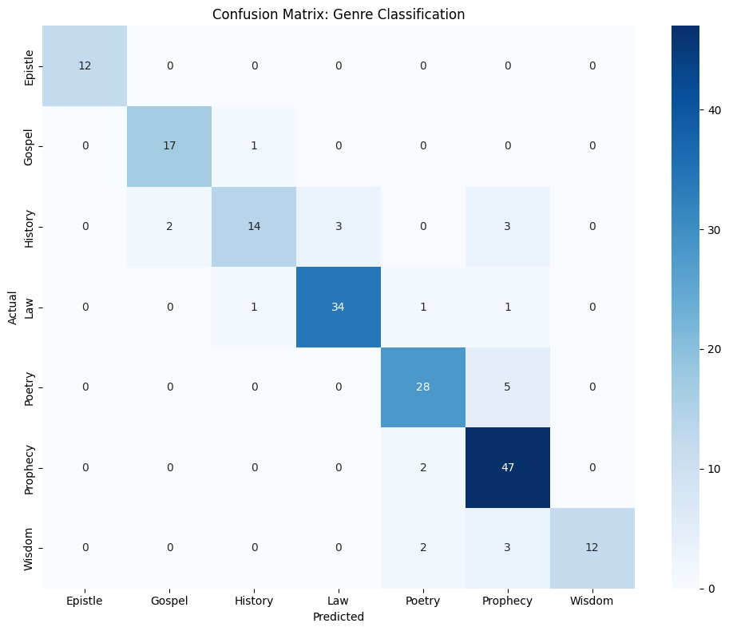

```python
#confusion matrix
plt.figure(figsize=(10, 8))
cm = confusion_matrix(y_test, y_pred, labels=rf.classes_)
sns.heatmap(cm, annot=True, fmt="d", cmap="Blues",
            xticklabels=rf.classes_, yticklabels=rf.classes_)
plt.xlabel("Predicted")
plt.ylabel("Actual")
plt.title("Confusion Matrix: Genre Classification")
plt.tight_layout()
plt.show()
```

## Interpreting the Confusion Matrix

The diagonal shows correct predictions & off-diagonal cells show misclassifications.

**Best performing genres:**

- **Epistle (12/12)** - Perfect classification. Letters have unique vocabulary.
- **Prophecy (47/49)** - Near perfect. Prophetic language is distinctive.
- **Gospel (17/18)** - Only 1 confused with History.

**Most confused genre:**

- **History (14/22)** - Only 64% correct. Often confused with:
  - Law (3 cases) - both Old Testament narrative
  - Prophecy (3 cases) - both describe Israel's story
  - Gospel (2 cases) - both use narrative style

**Common confusion patterns:**

- Poetry <-> Prophecy: Prophets often wrote in poetic style
- Wisdom <-> Poetry: Wisdom books (Proverbs, Ecclesiastes) use poetic forms
- History <-> law: Both share Old Testament narrative style

This makes sense because these genres genuinely share literary features!

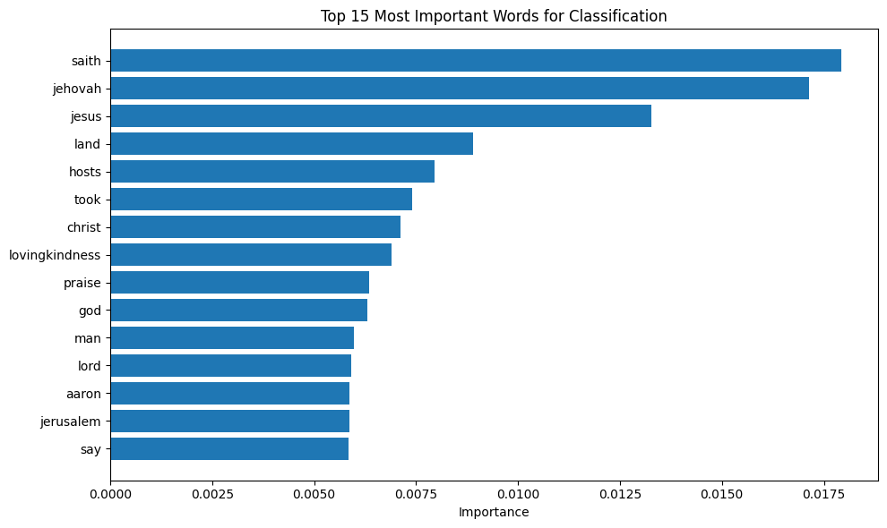

```python
#top 15 most important words
feature_names = tfidf.get_feature_names_out()
importances = rf.feature_importances_

top_indices = np.argsort(importances)[-15:]
top_words = [feature_names[i] for i in top_indices]
top_scores = [importances[i] for i in top_indices]

plt.figure(figsize=(10, 6))
plt.barh(top_words, top_scores)
plt.xlabel("Importance")
plt.title("Top 15 Most Important Words for Classification")
plt.tight_layout()
plt.show()
```

## Interpreting Feature Importance

Feature importance shows which words are most useful for distinguishing genres.

**Top discriminating words:**

- **saith** (most important) - Common in Prophecy ("thus saith the Lord"). Helps identify prophetic books.
- **jehovah** - The Hebrew name for God, used heavily in Old Testament (Law, History, Prophecy) but rarely in New Testament.
- **jesus** - Clearly separates New Testament (Gospel, Epistle) from Old Testament genres.
- **land** - Important in Law and History (promised land narratives).
- **hosts** - "Lord of hosts" is a prophetic phrase.
- **lovingkindness, praise** - Poetic/worship vocabulary, indicates Poetry (Psalms).
- **christ** - Theological term in Epistles and Gospels.
- **aaron** - Specific to Law (Exodus, Leviticus).

**Key insight:** The model learned meaningful patterns! Words that humans would associate with specific genres (prophetic language, names, worship terms) are exactly what the model found most useful.

## TEST WITH UNSEEN TEXT

```python
#predict genre of new text
def predict_genre(text):
    text_tfidf = tfidf.transform([text])
    return rf.predict(text_tfidf)[0]

#test eg
test_texts = [
    "In the beginning God created the heavens and the earth.",
    "Blessed is the man that walketh not in the counsel of the ungodly.",
    "For God so loved the world that he gave his only begotten Son."
]

print("Testing classifier:")
for text in test_texts:
    genre = predict_genre(text)
    print(f"\nText: \"{text[:50]}...\"")
    print(f"Predicted genre: {genre}")
```

```
Testing classifier:

Text: "In the beginning God created the heavens and the e..."
Predicted genre: Poetry

Text: "Blessed is the man that walketh not in the counsel..."
Predicted genre: Poetry

Text: "For God so loved the world that he gave his only b..."
Predicted genre: Poetry
```

## Conclusion

**Summary:**

- i used BERTopic to discover themes in Bible chapters
- added known genre labels (Law, History, Poetry, etc from a known source)
- trained Random Forest to classify chapters by genre
- almost 90% accuracy - good result

**Key findings:**